# Final Project

### References

- *Ortells, J. J., Kiefer, M., Castillo, A., Megías, M., & Morillas, A. (2016). The semantic origin of unconscious priming: Behavioral and event-related potential evidence during category congruency priming from strongly and weakly related masked words. Cognition, 146, 143–157. https://doi.org/10.1016/j.cognition.2015.09.012*
- *Bruno, N., Díaz Rivera, M., Embon, I., Iorio, A. (2016). Procesamiento Subliminal Según El Grado De Relación Semántica. VIII Congreso Internacional de Investigación y Práctica Profesional en Psicología. Facultad de Psicología - Universidad de Buenos Aires, Buenos Aires.*

Modeling dprime into the multilevel model.

Model 4 - Different intercepts (including dprime as fixed variable) $Y_{ij} = \alpha_{j[i]} + \beta1_i * \beta2_{j[i]} + \beta3_i + \beta4_{j[i]]} + \epsilon_i$

```r
# I would like to include dprime as a fixed effect with an interaction with SOA!
H_4 = lmer(log.RT ~ Relation * as.factor(SOA) + c.Num.Trial + c.dprime  + (1|ID) , data = df_no_error)
summary(H_4)
```

```
## Linear mixed model fit by REML ['lmerMod']
## Formula: log.RT ~ Relation * as.factor(SOA) + c.Num.Trial + c.dprime +
##     (1 | ID)
##    Data: df_no_error
##
## REML criterion at convergence: -9792.2
##
## Scaled residuals:
##     Min      1Q  Median      3Q     Max
## -3.7854 -0.6084 -0.1032  0.4582  6.5550
##
## Random effects:
##  Groups   Name        Variance Std.Dev.
##  ID       (Intercept) 0.01160  0.1077
##  Residual             0.03878  0.1969
## Number of obs: 25073, groups:  ID, 100
##
## Fixed effects:
##                                Estimate Std. Error t value
## (Intercept)                  -5.842e-01  2.407e-02 -24.268
## RelationWR                   -1.340e-02  6.075e-03  -2.206
## RelationSR                   -2.612e-02  6.082e-03  -4.295
## as.factor(SOA)66             -4.148e-02  3.936e-02  -1.054
## as.factor(SOA)150            -2.041e-02  3.378e-02  -0.604
## as.factor(SOA)233            -6.472e-02  3.065e-02  -2.112
## c.Num.Trial                   7.122e-05  1.686e-05   4.225
## c.dprime                     -1.840e-02  2.361e-02  -0.779
## RelationWR:as.factor(SOA)66  -5.831e-03  8.674e-03  -0.672
## RelationSR:as.factor(SOA)66   8.494e-03  8.683e-03   0.978
## RelationWR:as.factor(SOA)150 -8.583e-03  8.699e-03  -0.987
## RelationSR:as.factor(SOA)150 -4.497e-03  8.710e-03  -0.516
## RelationWR:as.factor(SOA)233  1.127e-03  8.455e-03   0.133
## RelationSR:as.factor(SOA)233  1.510e-02  8.453e-03   1.786
```

```
##
## Correlation matrix not shown by default, as p = 14 > 12.
## Use print(x, correlation=TRUE)  or
##     vcov(x)        if you need it
```

```
## refitting model(s) with ML (instead of REML)
```

```
## Data: df_no_error
## Models:
## H_difint: log.RT ~ Relation * as.factor(SOA) + c.Num.Trial + (1 | ID)
## H_4: log.RT ~ Relation * as.factor(SOA) + c.Num.Trial + c.dprime +
## H_4:     (1 | ID)
##          Df     AIC     BIC logLik deviance  Chisq Chi Df Pr(>Chisq)
## H_difint 15 -9878.1 -9756.2 4954.1  -9908.1
## H_4      16 -9876.8 -9746.7 4954.4  -9908.8 0.6373      1     0.4247
```

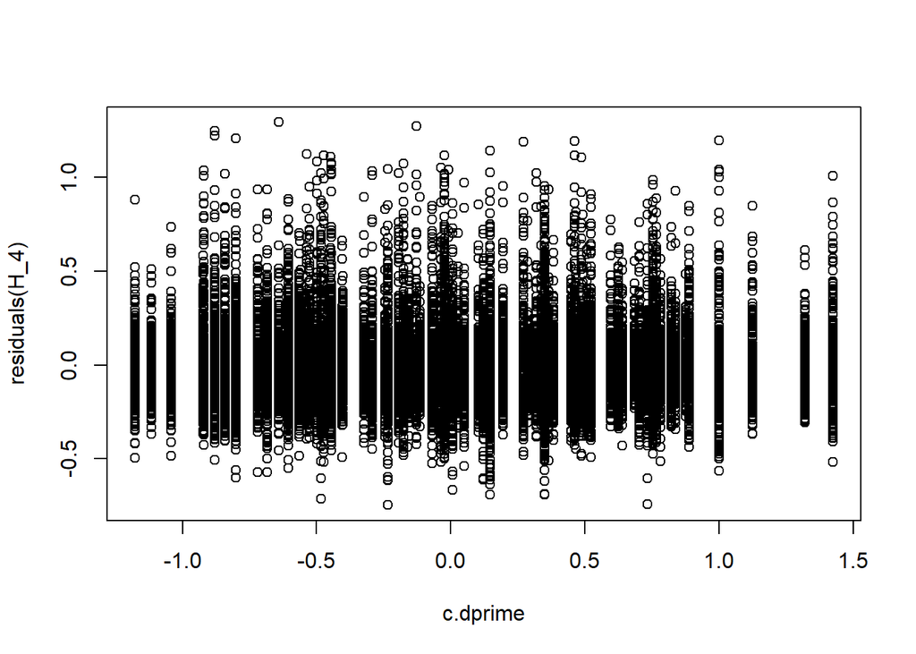

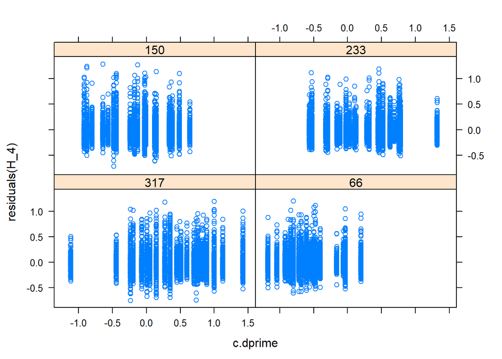

```r
plot(residuals(H_4)~c.dprime, data = df_no_error)
xyplot(residuals(H_4) ~ c.dprime | SOA , data = df_no_error)
anova(H_difint,H_4) #It does not look different, but theoretically should be possible. My first model would take in countt his dprime performance. But just to look possible outcomes  I will check.
```

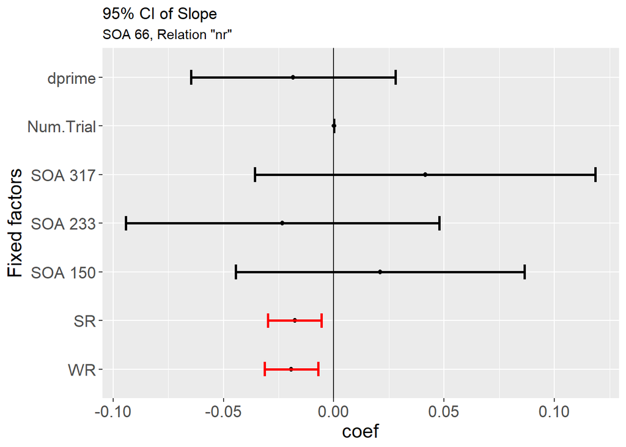

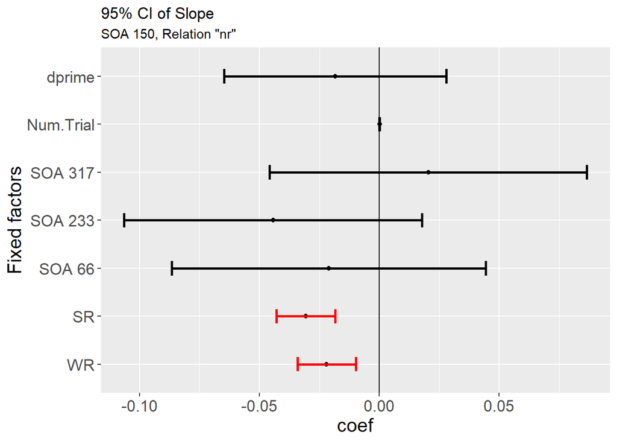

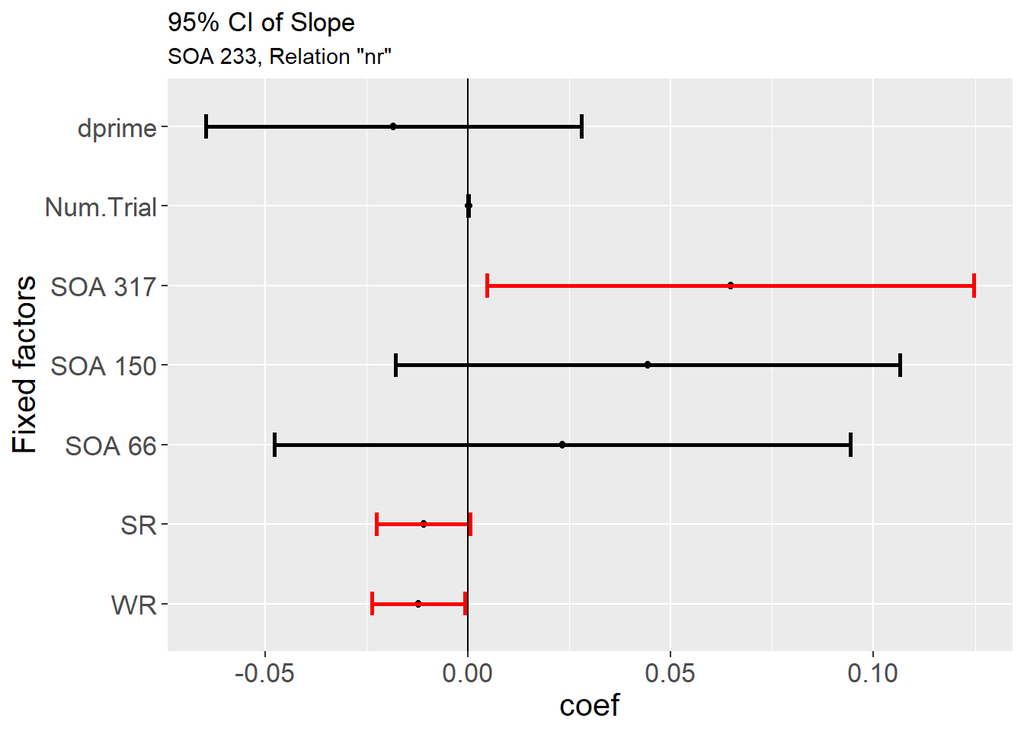

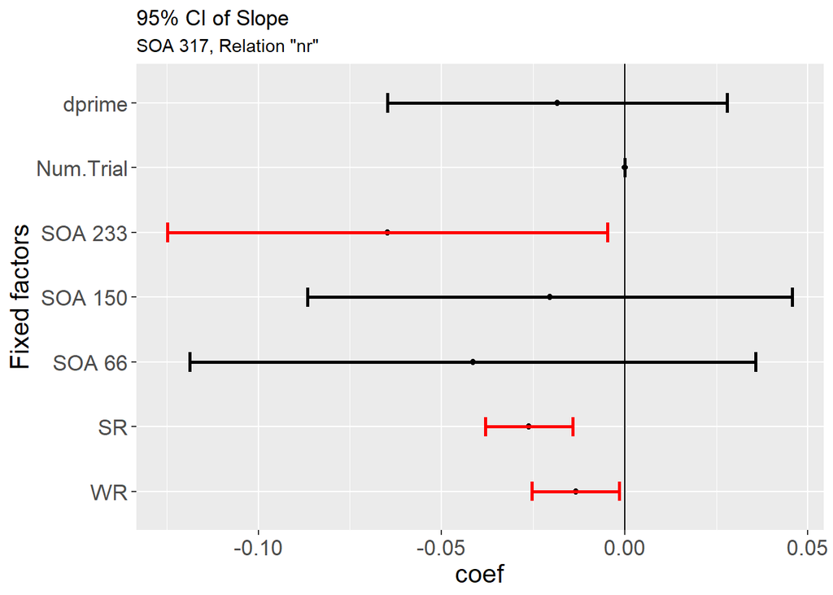

```r
#95 confindence interval multilevel model H_difint, baseline subject nr 66

df_no_error$SOA = factor(df_no_error$SOA, levels = c( '66','150','233','317'))
H_4 = lmer(log.RT ~ Relation * as.factor(SOA) + c.Num.Trial +  c.dprime  + (1|ID), data = df_no_error)
###############
coef = as.numeric(fixef(H_4)[-c(1, 9:14)])
conditions = factor(c("WR","SR", "SOA 150","SOA 233","SOA 317","Num.Trial","dprime"),levels = c("WR","SR", "SOA 150","SOA 233","SOA 317","Num.Trial","dprime"))
colores = c(1,1,0,0,0,0,0)
coef_pos = coef + c(1.96)* (influence.ME::se.fixef(H_4)[-c(1, 9:14)])
coef_neg = coef + c(-1.96)* (influence.ME::se.fixef(H_4)[-c(1, 9:14)])
coefs = data.frame(cbind(coef,coef_pos,coef_neg)) #,conditions))
##############
ggplot(data= coefs, aes(x = conditions,y= coef, color = colores)) +  geom_point(stat="identity", color="black", position=position_dodge( width = .2)) + geom_errorbar(aes(ymin=coef_neg, ymax=coef_pos),size= 1, width=.3, position=position_dodge()) + geom_hline(yintercept = 0) +
  labs( x = 'Fixed factors', title ='95% CI of Slope', subtitle= 'SOA 66, Relation "nr"') +
  theme(axis.text.x = element_text(size=rel(1.5)),
        axis.text.y = element_text(size=rel(1.5)),
        axis.title.x = element_text(size = rel(1.4)),
        axis.title.y = element_text(size = rel(1.4)), legend.position = 'none' ) + coord_flip() + scale_color_gradient(low = "black", high = "red")




#-------------------------------------------------------------------------
#95 confindence interval multilevel model H_difint, baseline subject nr 150

df_no_error$SOA = factor(df_no_error$SOA, levels = c( '150','66','233','317'))
H_4 = lmer(log.RT ~ Relation * as.factor(SOA) + c.Num.Trial +  c.dprime  + (1|ID), data = df_no_error)
###############
coef = as.numeric(fixef(H_4)[-c(1, 9:14)])
conditions = factor(c("WR","SR", "SOA 66","SOA 233","SOA 317","Num.Trial","dprime"),levels = c("WR","SR", "SOA 66","SOA 233","SOA 317","Num.Trial","dprime"))
colores = c(1,1,0,0,0,0,0)
coef_pos = coef + c(1.96)* (influence.ME::se.fixef(H_4)[-c(1, 9:14)])
coef_neg = coef + c(-1.96)* (influence.ME::se.fixef(H_4)[-c(1, 9:14)])
coefs = data.frame(cbind(coef,coef_pos,coef_neg)) #,conditions))
##############
ggplot(data= coefs, aes(x = conditions,y= coef, color = colores)) +  geom_point(stat="identity", color="black", position=position_dodge( width = .2)) + geom_errorbar(aes(ymin=coef_neg, ymax=coef_pos),size= 1, width=.3, position=position_dodge()) + geom_hline(yintercept = 0) +
  labs( x = 'Fixed factors', title ='95% CI of Slope', subtitle= 'SOA 150, Relation "nr"') +
  theme(axis.text.x = element_text(size=rel(1.5)),
        axis.text.y = element_text(size=rel(1.5)),
        axis.title.x = element_text(size = rel(1.4)),
        axis.title.y = element_text(size = rel(1.4)), legend.position = 'none' ) + coord_flip() + scale_color_gradient(low = "black", high = "red")


#-------------------------------------------------------------------------
#95 confindence interval multilevel model H_difint, baseline subject nr 233

df_no_error$SOA = factor(df_no_error$SOA, levels = c( '233','66','150','317'))
H_4 = lmer(log.RT ~ Relation * as.factor(SOA) + c.Num.Trial +  c.dprime  + (1|ID), data = df_no_error)
###############
coef = as.numeric(fixef(H_4)[-c(1, 9:14)])
conditions = factor(c("WR","SR", "SOA 66","SOA 150","SOA 317","Num.Trial","dprime"),levels = c("WR","SR", "SOA 66","SOA 150","SOA 317","Num.Trial","dprime"))
colores = c(1,1,0,0,1,0,0)
coef_pos = coef + c(1.96)* (influence.ME::se.fixef(H_4)[-c(1, 9:14)])
coef_neg = coef + c(-1.96)* (influence.ME::se.fixef(H_4)[-c(1, 9:14)])
coefs = data.frame(cbind(coef,coef_pos,coef_neg)) #,conditions))
##############
ggplot(data= coefs, aes(x = conditions,y= coef, color = colores)) +  geom_point(stat="identity", color="black", position=position_dodge( width = .2)) + geom_errorbar(aes(ymin=coef_neg, ymax=coef_pos),size= 1, width=.3, position=position_dodge()) + geom_hline(yintercept = 0) +
  labs( x = 'Fixed factors', title ='95% CI of Slope', subtitle= 'SOA 233, Relation "nr"') +
  theme(axis.text.x = element_text(size=rel(1.5)),
        axis.text.y = element_text(size=rel(1.5)),
        axis.title.x = element_text(size = rel(1.4)),
        axis.title.y = element_text(size = rel(1.4)), legend.position = 'none' ) + coord_flip() + scale_color_gradient(low = "black", high = "red")



#-------------------------------------------------------------------------
#95 confindence interval multilevel model H_difint, baseline subject nr 317

df_no_error$SOA = factor(df_no_error$SOA, levels = c( '317','66','150','233'))
H_4 = lmer(log.RT ~ Relation * as.factor(SOA) + c.Num.Trial +  c.dprime  + (1|ID), data = df_no_error)
###############
coef = as.numeric(fixef(H_4)[-c(1, 9:14)])
conditions = factor(c("WR","SR", "SOA 66","SOA 150","SOA 233","Num.Trial","dprime"),levels = c("WR","SR", "SOA 66","SOA 150","SOA 233","Num.Trial","dprime"))
colores = c(1,1,0,0,1,0,0)
coef_pos = coef + c(1.96)* (influence.ME::se.fixef(H_4)[-c(1, 9:14)])
coef_neg = coef + c(-1.96)* (influence.ME::se.fixef(H_4)[-c(1, 9:14)])
coefs = data.frame(cbind(coef,coef_pos,coef_neg)) #,conditions))
##############
ggplot(data= coefs, aes(x = conditions,y= coef, color = colores)) +  geom_point(stat="identity", color="black", position=position_dodge( width = .2)) + geom_errorbar(aes(ymin=coef_neg, ymax=coef_pos),size= 1, width=.3, position=position_dodge()) + geom_hline(yintercept = 0) +
  labs( x = 'Fixed factors', title ='95% CI of Slope', subtitle= 'SOA 317, Relation "nr"') +
  theme(axis.text.x = element_text(size=rel(1.5)),
        axis.text.y = element_text(size=rel(1.5)),
        axis.title.x = element_text(size = rel(1.4)),
        axis.title.y = element_text(size = rel(1.4)), legend.position = 'none' ) + coord_flip() + scale_color_gradient(low = "black", high = "red")
```